# PSTAT 131 Final Project- Ankita Pattnaik

# Models

## Classification Tree

I first decided to fit my data to classification trees.

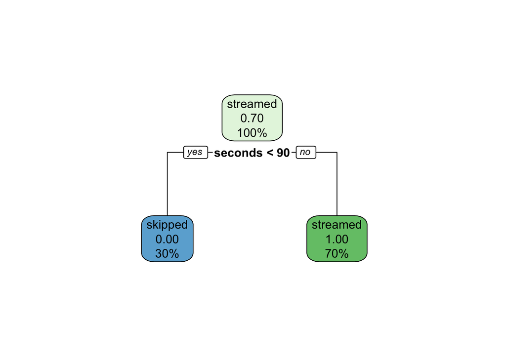

```r
#fitting classification trees
tree_spec <- decision_tree() %>%
  set_engine("rpart")
class_tree_spec <- tree_spec %>%
  set_mode("classification")
class_tree_fit <- class_tree_spec %>%
  fit(skipped ~ ., data = spotify_train)
#to implement a little of what we learned LOL this classification decision tree is a LOL though. really put into prespective how my skipped and streamed variables go though :)
class_tree_fit %>%
  extract_fit_engine() %>%
  rpart.plot(roundint = FALSE)
```

Nothing much to see here, it is what it is.

## Check Accuracy

I then decided to check my training set accuracy because that’s how we approached the classification tree in class.

```r
#check training set accuracy
augment(class_tree_fit, new_data = spotify_train) %>%
  accuracy(truth = skipped, estimate = .pred_class)
```

```
## # A tibble: 1 × 3
##   .metric  .estimator .estimate
##   <chr>    <chr>          <dbl>
## 1 accuracy binary             1
```

```r
#very accurate

#check confusion matrix
augment(class_tree_fit, new_data = spotify_train) %>%
  conf_mat(truth = skipped, estimate = .pred_class)
```

```
##           Truth
## Prediction skipped streamed
##   skipped      704        0
##   streamed       0     1637
```

Again, nothing much to see here because my data is collinear. But it is interesting to see how the data is distributed to skipped and streamed.

## Folding Data

I then, folded the data using vfold with v=10 and repeat =2. I created an accuracy grid with my accuracy data.

```r
set.seed(2435)
spotify_fold <- vfold_cv(spotify_train, strata = skipped, v = 10, repeats = 2, na.rm= TRUE)
```

## Accuracy Grid

Decision Tree

```r
#tree
tree_spec <- decision_tree() %>%
  set_engine("rpart")
class_tree_spec <- tree_spec %>%
  set_mode("classification")
class_tree_wf <- workflow() %>%
  add_model(class_tree_spec %>% set_args(cost_complexity = tune())) %>%
  add_recipe(spotify_recipe)

###  accuracy grid
param_grid1 <- grid_regular(cost_complexity(range = c(-3, -1)), levels = 10)
```

```r
tune_res_accuracy <- tune_grid(
  class_tree_wf,
  resamples = spotify_fold,
  grid = param_grid1,
  metrics = metric_set(accuracy)
)
save(tune_res_accuracy,file="tune_res_acc.rda")
```

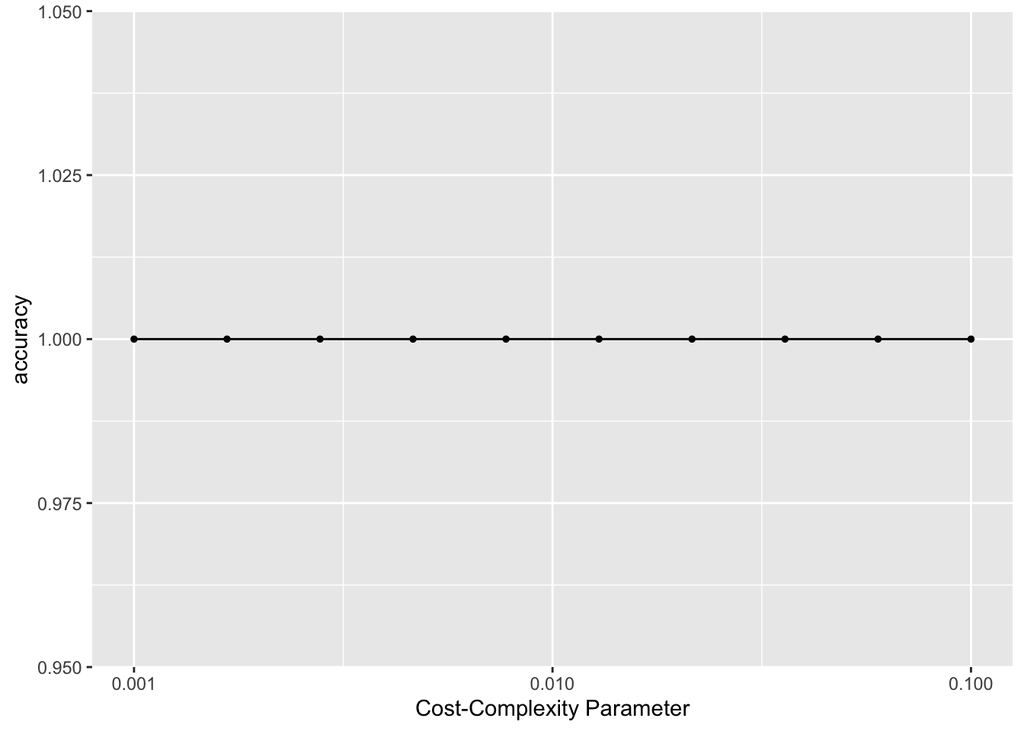

```r
load("tune_res_acc.rda")
autoplot(tune_res_accuracy)
```

```r
#we could have predicted this from our decision tree because it was either 1 or 0.
```

This graph continues to prove and show that my data has nothing much to work with other than 0 or 1. My accuracy is clearly 1 here, amazing! I mean of course we can assume I streamed the song. VERY GOOD ACCURACY :D

## Elastic Net

I then decided to create an elastic net, again, approaching my data the way we had on the homeworks and labs.

```r
### fitting and tuning an elastic net
elastic_net_spec <- multinom_reg(penalty = tune(),
                                 mixture = tune()) %>%
  set_mode("classification") %>%
  set_engine("glmnet")

en_workflow <- workflow() %>%
  add_recipe(spotify_recipe) %>%
  add_model(elastic_net_spec)

en_grid <- grid_regular(penalty(range = c(-5, 5)),
                        mixture(range = c(0, 1)), levels = 10)
#fit models to folded data
```

```r
tune_res_en <- tune_grid(
  en_workflow,
  resamples = spotify_fold,
  grid = en_grid
)
save(tune_res_en,file="tune_res_en.rda")
```

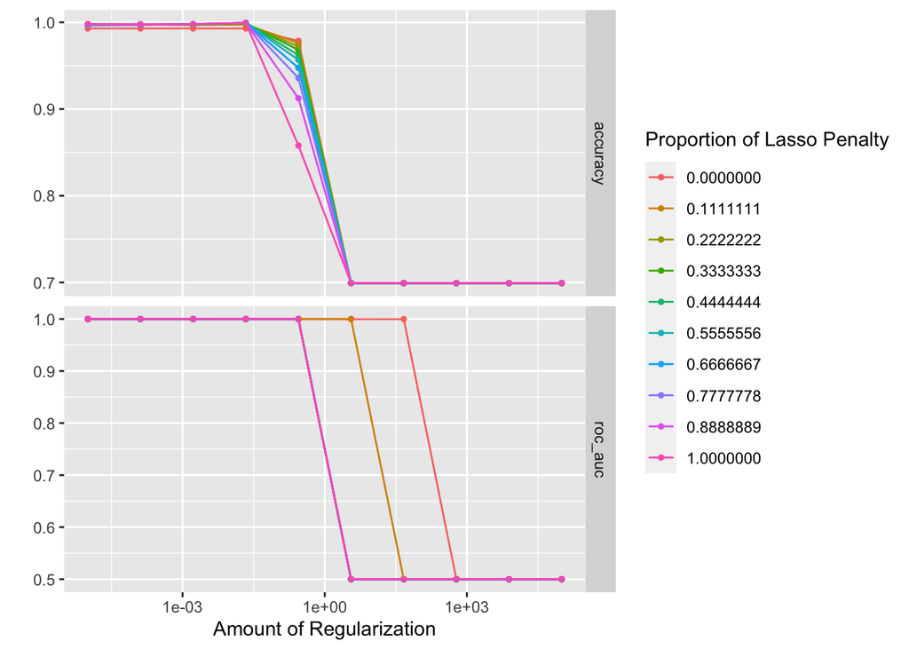

```r
load("tune_res_en.rda")
autoplot(tune_res_en)
```

We can continue to see the consistenct in collinearity.

```r
 collect_metrics(tune_res_en)%>%
  arrange(-mean)
```

```
## # A tibble: 200 × 8
##    penalty mixture .metric .estimator  mean     n std_err .config
##      <dbl>   <dbl> <chr>   <chr>      <dbl> <int>   <dbl> <chr>
##  1  0.278    0.111 roc_auc binary         1    20       0 Preprocessor1_Model015
##  2  3.59     0.111 roc_auc binary         1    20       0 Preprocessor1_Model016
##  3  0.278    0.222 roc_auc binary         1    20       0 Preprocessor1_Model025
##  4  0.278    0.333 roc_auc binary         1    20       0 Preprocessor1_Model035
##  5  0.0215   0.444 roc_auc binary         1    20       0 Preprocessor1_Model044
##  6  0.278    0.444 roc_auc binary         1    20       0 Preprocessor1_Model045
##  7  0.0215   0.556 roc_auc binary         1    20       0 Preprocessor1_Model054
##  8  0.278    0.556 roc_auc binary         1    20       0 Preprocessor1_Model055
##  9  0.0215   0.667 roc_auc binary         1    20       0 Preprocessor1_Model064
## 10  0.278    0.667 roc_auc binary         1    20       0 Preprocessor1_Model065
## # … with 190 more rows
```

Once again, a mean= 1.0000000.

```r
#boosted model
bt_spec <- boost_tree() %>%
  set_engine("xgboost") %>%
  set_mode("classification")
bt_wf <- workflow() %>%
  add_model(bt_spec %>% set_args(trees = tune())) %>%
  add_recipe(spotify_recipe)
param_grid3 <- grid_regular(trees(range = c(10,2000)), levels = 10)
```

```r
tune_res_bt <- tune_grid(
  bt_wf,
  resamples = spotify_fold,
  grid = param_grid3,
  metrics = metric_set(roc_auc)
)
save(tune_res_bt,file="tune_res_bt.rda")
```

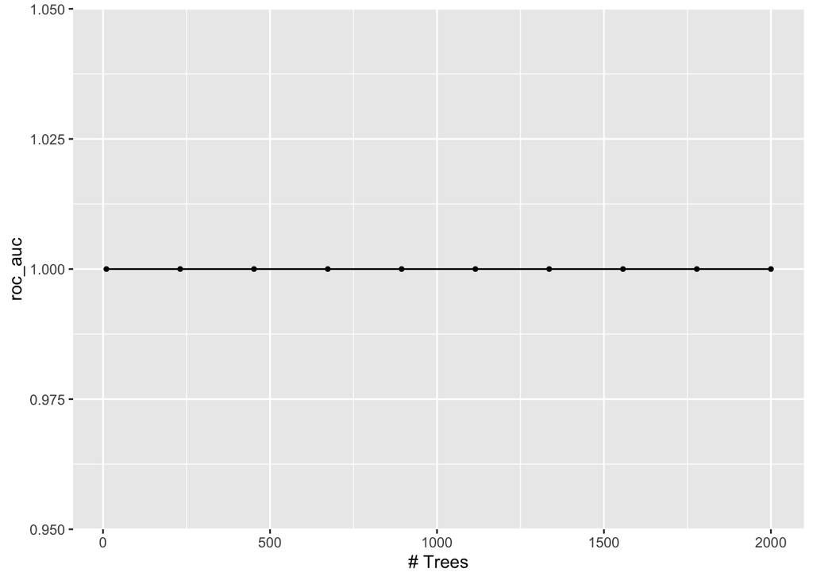

```r
load("tune_res_bt.rda")
autoplot(tune_res_bt)
```

Once again, through roc_auc I wanted to see it under the `collect_metrics()` function. Same results.

```r
#we can see the details of the plot here
collect_metrics(tune_res_bt)%>%
  arrange(-mean)
```

```
## # A tibble: 10 × 7
##    trees .metric .estimator  mean     n std_err .config
##    <int> <chr>   <chr>      <dbl> <int>   <dbl> <chr>
##  1    10 roc_auc binary         1    20       0 Preprocessor1_Model01
##  2   231 roc_auc binary         1    20       0 Preprocessor1_Model02
##  3   452 roc_auc binary         1    20       0 Preprocessor1_Model03
##  4   673 roc_auc binary         1    20       0 Preprocessor1_Model04
##  5   894 roc_auc binary         1    20       0 Preprocessor1_Model05
##  6  1115 roc_auc binary         1    20       0 Preprocessor1_Model06
##  7  1336 roc_auc binary         1    20       0 Preprocessor1_Model07
##  8  1557 roc_auc binary         1    20       0 Preprocessor1_Model08
##  9  1778 roc_auc binary         1    20       0 Preprocessor1_Model09
## 10  2000 roc_auc binary         1    20       0 Preprocessor1_Model10
```

Let’s get it off the table. My data, was not the most ideal to work with. It was because of my response variable. The approach I had on my dataset was the same that was applied on the way we analyzed the `titanic` dataset in class and through section. The response variable in those yielded `yes` or `no`, on whether someone survived or not. The same way I interpreted my `streamed` or `skipped` to see if I had streamed the song or skipped it instead.

I am sure if I had chosen `minutes_played` as the response variable, I could have yielded a variety of results. However, as I continued to work on my data and tackle more and more errors, the outputs of my code didn’t start successfully running until last week. Even then, I had numerous errors and I couldn’t have completed my code without the help of my peers, shoutout to Ryan C., I think you had him a previous quarter!

While I could have changed my response variable, I didn’t feel comfortable doing it so last minute and have to reinterpret my data.

This project to me, is a fail in terms of analysis but really taught me how to hash out my errors and really debug a lot of my work. Because the errors were so specific to model tuning and trees, it was difficult to find online sources to help there were only so many. Even then, the circumstances of my code were too different so I really had to think and work on debugging my code.

I debugged so much I came up with the phrase “new error, new ground” because as each error changed to another I had to spend a few hours fixing it. I really underestimated the trouble my code and dataset would give me.

So overall, with my analysis it is safe to say that I will be streaming whichever song I decide to play. I don’t listen to music often but we can assume it would be DAY6, or KPOP, and that I would not skip the song.